# Part A

### **C. Print evaluation metrics for final model.**

```python
# Classification Report for KNN
print(classification_report(y_test, y_pred5, target_names=target_names))
```

```
              precision    recall  f1-score   support

           1       0.97      0.99      0.98      1139
           0       0.86      0.72      0.78       106

    accuracy                           0.97      1245
   macro avg       0.92      0.85      0.88      1245
weighted avg       0.96      0.97      0.96      1245
```

```python
# Classification Report for SVM
print(classification_report(y_test, svc_y_pred6, target_names=target_names))
```

```
              precision    recall  f1-score   support

           1       0.98      1.00      0.99      1139
           0       0.94      0.77      0.85       106

    accuracy                           0.98      1245
   macro avg       0.96      0.88      0.92      1245
weighted avg       0.98      0.98      0.98      1245
```

```python
# Print ROC_AUC Score for KNN
print(f'Area Under Curve for KNN: {roc_auc_score(y_test, y_pred5)}')
```

```
Area Under Curve for KNN: 0.8532227872844433
```

```python
# Print ROC_AUC Score for SVM
print(f'Area Under Curve for SVM: {roc_auc_score(y_test, svc_y_pred6)}')
```

```
Area Under Curve for SVM: 0.8845975450163168
```

```
Confusion Matrix - KNN
```

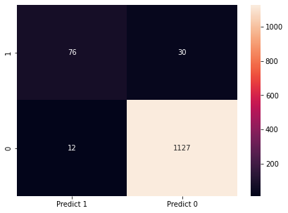

```python
# Print Confusion Matrix for KNN
print('Confusion Matrix - KNN')
cm=metrics.confusion_matrix(y_test, y_pred5, labels=[1, 0])

df_cm = pd.DataFrame(cm, index = [i for i in ["1","0"]],
                  columns = [i for i in ["Predict 1","Predict 0"]])
plt.figure(figsize = (7,5))
sns.heatmap(df_cm, annot=True, fmt='d');
```

```
Confusion Matrix - SVM
```

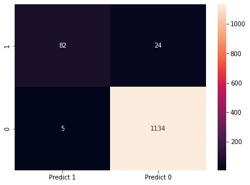

```python
# Print Confusion Matrix for SVM
print('Confusion Matrix - SVM')
cm=metrics.confusion_matrix(y_test, svc_y_pred6, labels=[1, 0])

df_cm = pd.DataFrame(cm, index = [i for i in ["1","0"]],
                  columns = [i for i in ["Predict 1","Predict 0"]])
plt.figure(figsize = (7,5))
sns.heatmap(df_cm, annot=True, fmt='d');
```

### **D. Share improvement achieved from base model to final model.**

*Improvement in Performance Metrics of Modified KNN Model Over Base Model*

- *Precision Improvement*
  - *'Class 1': +2%*
  - *'Class 0': +41%*
- *Recall Improvement*
  - *'Class 1': +3%*
  - *'Class 0': +30%*
- *F1-Score Improvement*
  - *'Class 1': +3%*
  - *'Class 0': +33%*
- *An increase in accuracy of +6% is also observed.*
- *AUC Improved by 17%*

*From the confusion matrix*

*True Positives (TP): we correctly predicted that they do have LoanOnCard 76 (an increase from 44 from base model)*

*True Negatives (TN): we correctly predicted that they don't have LoanOnCard 1127 (an increase from 1094 from base model)*

*False Positives (FP): we incorrectly predicted that they do have LoanOnCard (a "Type I error") 12 Falsely predict positive Type I error (a reduction from 45 from base model)*

*False Negatives (FN): we incorrectly predicted that they don't have diabetes (a "Type II error") 30 Falsely predict negative Type II error (a reduction from 62 from base model)*

*Improvement in Performance Metrics of Modified SVM Model Over Base Model*

- *Precision Improvement*
  - *'Class 1': +6%*
  - *'Class 0': +49%*
- *Recall Improvement*
  - *'Class 1': +2%*
  - *'Class 0': +63%*
- *F1-Score Improvement*
  - *'Class 1': +4%*
  - *'Class 0': +63%*
- *An increase in accuracy of +7% is also observed.*
- *AUC Improved by 32%*

*From the confusion matrix*

*True Positives (TP): we correctly predicted that they do have LoanOnCard 82 (an increase from 15 from base model)*

*True Negatives (TN): we correctly predicted that they don't have LoanOnCard 1134 (an increase from 1121 from base model)*

*False Positives (FP): we incorrectly predicted that they do have LoanOnCard (a "Type I error") 5 Falsely predict positive Type I error (a reduction from 18 from base model)*

*False Negatives (FN): we incorrectly predicted that they don't have diabetes (a "Type II error") 24 Falsely predict negative Type II error (a reduction from 91 from base model)*